# Exploring the Most Popular Programming on Netflix

Author

Zhuohan Sun

# Introduction

Netflix is one of the world’s leading streaming platforms, recognized for its broad slate of films and series. Using Netflix Top 10 data, we analyze which titles break out and how popularity differs across countries. The goal is to pinpoint markets with outsized demand and identify where targeted commissioning, localization, and marketing can unlock stronger traffic and growth. This report highlights the regions and countries most likely to become Netflix’s next growth engines.

# Acquire Data

```r
if(!dir.exists(file.path("data", "mp01"))){
    dir.create(file.path("data", "mp01"), showWarnings=FALSE, recursive=TRUE)
}

GLOBAL_TOP_10_FILENAME <- file.path("data", "mp01", "global_top10_alltime.csv")

if(!file.exists(GLOBAL_TOP_10_FILENAME)){
    download.file("https://www.netflix.com/tudum/top10/data/all-weeks-global.tsv",
                  destfile=GLOBAL_TOP_10_FILENAME)
}

COUNTRY_TOP_10_FILENAME <- file.path("data", "mp01", "country_top10_alltime.csv")

if(!file.exists(COUNTRY_TOP_10_FILENAME)){
    download.file("https://www.netflix.com/tudum/top10/data/all-weeks-countries.tsv",
                  destfile=COUNTRY_TOP_10_FILENAME)
}
```

# Data Import and Preparation

## GLOBAL_TOP_10

```r
if(!require("tidyverse")) install.packages("tidyverse")
library(readr)
library(dplyr)

GLOBAL_TOP_10 <- read_tsv(GLOBAL_TOP_10_FILENAME)
```

```r
glimpse(GLOBAL_TOP_10)
```

```
Rows: 8,880
Columns: 9
$ week                       <date> 2025-09-28, 2025-09-28, 2025-09-28, 2025-0…
$ category                   <chr> "Films (English)", "Films (English)", "Film…
$ weekly_rank                <dbl> 1, 2, 3, 4, 5, 6, 7, 8, 9, 10, 1, 2, 3, 4, …
$ show_title                 <chr> "KPop Demon Hunters", "Ruth & Boaz", "The W…
$ season_title               <chr> "N/A", "N/A", "N/A", "N/A", "N/A", "N/A", "…
$ weekly_hours_viewed        <dbl> 32200000, 15900000, 13500000, 15700000, 112…
$ runtime                    <dbl> 1.6667, 1.5500, 1.7833, 2.4333, 1.8333, 1.7…
$ weekly_views               <dbl> 19300000, 10300000, 7600000, 6500000, 61000…
$ cumulative_weeks_in_top_10 <dbl> 15, 1, 3, 5, 2, 1, 1, 1, 1, 3, 2, 1, 1, 2, …
```

```r
GLOBAL_TOP_10 <- GLOBAL_TOP_10 |>
    mutate(season_title = if_else(season_title == "N/A", NA_character_, season_title))
```

```r
glimpse(GLOBAL_TOP_10)
```

```
Rows: 8,880
Columns: 9
$ week                       <date> 2025-09-28, 2025-09-28, 2025-09-28, 2025-0…
$ category                   <chr> "Films (English)", "Films (English)", "Film…
$ weekly_rank                <dbl> 1, 2, 3, 4, 5, 6, 7, 8, 9, 10, 1, 2, 3, 4, …
$ show_title                 <chr> "KPop Demon Hunters", "Ruth & Boaz", "The W…
$ season_title               <chr> NA, NA, NA, NA, NA, NA, NA, NA, NA, "aka Ch…
$ weekly_hours_viewed        <dbl> 32200000, 15900000, 13500000, 15700000, 112…
$ runtime                    <dbl> 1.6667, 1.5500, 1.7833, 2.4333, 1.8333, 1.7…
$ weekly_views               <dbl> 19300000, 10300000, 7600000, 6500000, 61000…
$ cumulative_weeks_in_top_10 <dbl> 15, 1, 3, 5, 2, 1, 1, 1, 1, 3, 2, 1, 1, 2, …
```

## COUNTRY_TOP_10

```r
if(!require("tidyverse")) install.packages("tidyverse")
library(readr)
library(dplyr)

COUNTRY_TOP_10 <- read_tsv(COUNTRY_TOP_10_FILENAME)
```

```r
glimpse(COUNTRY_TOP_10)
```

```
Rows: 413,620
Columns: 8
$ country_name               <chr> "Argentina", "Argentina", "Argentina", "Arg…
$ country_iso2               <chr> "AR", "AR", "AR", "AR", "AR", "AR", "AR", "…
$ week                       <date> 2025-09-28, 2025-09-28, 2025-09-28, 2025-0…
$ category                   <chr> "Films", "Films", "Films", "Films", "Films"…
$ weekly_rank                <dbl> 1, 2, 3, 4, 5, 6, 7, 8, 9, 10, 1, 2, 3, 4, …
$ show_title                 <chr> "Sonic the Hedgehog 3", "KPop Demon Hunters…
$ season_title               <chr> "N/A", "N/A", "N/A", "N/A", "N/A", "N/A", "…
$ cumulative_weeks_in_top_10 <dbl> 2, 15, 1, 2, 1, 1, 2, 5, 1, 2, 2, 1, 1, 1, …
```

```r
COUNTRY_TOP_10 <- COUNTRY_TOP_10 |>
    mutate(season_title = if_else(season_title == "N/A", NA_character_, season_title))
```

```r
glimpse(COUNTRY_TOP_10)
```

```
Rows: 413,620
Columns: 8
$ country_name               <chr> "Argentina", "Argentina", "Argentina", "Arg…
$ country_iso2               <chr> "AR", "AR", "AR", "AR", "AR", "AR", "AR", "…
$ week                       <date> 2025-09-28, 2025-09-28, 2025-09-28, 2025-0…
$ category                   <chr> "Films", "Films", "Films", "Films", "Films"…
$ weekly_rank                <dbl> 1, 2, 3, 4, 5, 6, 7, 8, 9, 10, 1, 2, 3, 4, …
$ show_title                 <chr> "Sonic the Hedgehog 3", "KPop Demon Hunters…
$ season_title               <chr> NA, NA, NA, NA, NA, NA, NA, NA, NA, NA, "Bi…
$ cumulative_weeks_in_top_10 <dbl> 2, 15, 1, 2, 1, 1, 2, 5, 1, 2, 2, 1, 1, 1, …
```

```r
library(DT)
GLOBAL_TOP_10 |>
    head(n=20) |>
    datatable(options=list(searching=FALSE, info=FALSE))
```

|  | week | category | weekly_rank | show_title | season_title | weekly_hours_viewed | runtime | weekly_views | cumulative_weeks_in_top_10 |
| --- | --- | --- | --- | --- | --- | --- | --- | --- | --- |
| 1 | 2025-09-28 | Films (English) | 1 | KPop Demon Hunters |  | 32200000 | 1.6667 | 19300000 | 15 |
| 2 | 2025-09-28 | Films (English) | 2 | Ruth &amp; Boaz |  | 15900000 | 1.55 | 10300000 | 1 |
| 3 | 2025-09-28 | Films (English) | 3 | The Wrong Paris |  | 13500000 | 1.7833 | 7600000 | 3 |
| 4 | 2025-09-28 | Films (English) | 4 | Man on Fire |  | 15700000 | 2.4333 | 6500000 | 5 |
| 5 | 2025-09-28 | Films (English) | 5 | Sonic the Hedgehog 3 |  | 11200000 | 1.8333 | 6100000 | 2 |
| 6 | 2025-09-28 | Films (English) | 6 | Seventh Son |  | 8400000 | 1.7 | 4900000 | 1 |
| 7 | 2025-09-28 | Films (English) | 7 | San Andreas |  | 6800000 | 1.9 | 3600000 | 1 |
| 8 | 2025-09-28 | Films (English) | 8 | 28 Years Later |  | 6200000 | 1.9167 | 3200000 | 1 |
| 9 | 2025-09-28 | Films (English) | 9 | The Curse of La Llorona |  | 4900000 | 1.55 | 3200000 | 1 |
| 10 | 2025-09-28 | Films (English) | 10 | aka Charlie Sheen | aka Charlie Sheen: Season 1 | 8400000 | 3.0333 | 2800000 | 3 |

[output cut: 10 more lines]

```r
library(stringr)
format_titles <- function(df){
    colnames(df) <- str_replace_all(colnames(df), "_", " ") |> str_to_title()
    df
}

GLOBAL_TOP_10 |>
    format_titles() |>
    head(n=20) |>
    datatable(options=list(searching=FALSE, info=FALSE)) |>
    formatRound(c('Weekly Hours Viewed', 'Weekly Views'))
```

|  | Week | Category | Weekly Rank | Show Title | Season Title | Weekly Hours Viewed | Runtime | Weekly Views | Cumulative Weeks In Top 10 |
| --- | --- | --- | --- | --- | --- | --- | --- | --- | --- |
| 1 | 2025-09-28 | Films (English) | 1 | KPop Demon Hunters |  | 32200000 | 1.6667 | 19300000 | 15 |
| 2 | 2025-09-28 | Films (English) | 2 | Ruth &amp; Boaz |  | 15900000 | 1.55 | 10300000 | 1 |
| 3 | 2025-09-28 | Films (English) | 3 | The Wrong Paris |  | 13500000 | 1.7833 | 7600000 | 3 |
| 4 | 2025-09-28 | Films (English) | 4 | Man on Fire |  | 15700000 | 2.4333 | 6500000 | 5 |
| 5 | 2025-09-28 | Films (English) | 5 | Sonic the Hedgehog 3 |  | 11200000 | 1.8333 | 6100000 | 2 |
| 6 | 2025-09-28 | Films (English) | 6 | Seventh Son |  | 8400000 | 1.7 | 4900000 | 1 |
| 7 | 2025-09-28 | Films (English) | 7 | San Andreas |  | 6800000 | 1.9 | 3600000 | 1 |
| 8 | 2025-09-28 | Films (English) | 8 | 28 Years Later |  | 6200000 | 1.9167 | 3200000 | 1 |
| 9 | 2025-09-28 | Films (English) | 9 | The Curse of La Llorona |  | 4900000 | 1.55 | 3200000 | 1 |
| 10 | 2025-09-28 | Films (English) | 10 | aka Charlie Sheen | aka Charlie Sheen: Season 1 | 8400000 | 3.0333 | 2800000 | 3 |

[output cut: 10 more lines]

```r
GLOBAL_TOP_10 |>
    select(-season_title) |>
    format_titles() |>
    head(n=20) |>
    datatable(options=list(searching=FALSE, info=FALSE)) |>
    formatRound(c('Weekly Hours Viewed', 'Weekly Views'))
```

|  | Week | Category | Weekly Rank | Show Title | Weekly Hours Viewed | Runtime | Weekly Views | Cumulative Weeks In Top 10 |
| --- | --- | --- | --- | --- | --- | --- | --- | --- |
| 1 | 2025-09-28 | Films (English) | 1 | KPop Demon Hunters | 32200000 | 1.6667 | 19300000 | 15 |
| 2 | 2025-09-28 | Films (English) | 2 | Ruth &amp; Boaz | 15900000 | 1.55 | 10300000 | 1 |
| 3 | 2025-09-28 | Films (English) | 3 | The Wrong Paris | 13500000 | 1.7833 | 7600000 | 3 |
| 4 | 2025-09-28 | Films (English) | 4 | Man on Fire | 15700000 | 2.4333 | 6500000 | 5 |
| 5 | 2025-09-28 | Films (English) | 5 | Sonic the Hedgehog 3 | 11200000 | 1.8333 | 6100000 | 2 |
| 6 | 2025-09-28 | Films (English) | 6 | Seventh Son | 8400000 | 1.7 | 4900000 | 1 |
| 7 | 2025-09-28 | Films (English) | 7 | San Andreas | 6800000 | 1.9 | 3600000 | 1 |
| 8 | 2025-09-28 | Films (English) | 8 | 28 Years Later | 6200000 | 1.9167 | 3200000 | 1 |
| 9 | 2025-09-28 | Films (English) | 9 | The Curse of La Llorona | 4900000 | 1.55 | 3200000 | 1 |
| 10 | 2025-09-28 | Films (English) | 10 | aka Charlie Sheen | 8400000 | 3.0333 | 2800000 | 3 |

[output cut: 10 more lines]

```r
GLOBAL_TOP_10 |>
    mutate(`runtime_(minutes)` = round(60 * runtime)) |>
    select(-season_title,
           -runtime) |>
    format_titles() |>
    head(n=20) |>
    datatable(options=list(searching=FALSE, info=FALSE)) |>
    formatRound(c('Weekly Hours Viewed', 'Weekly Views'))
```

|  | Week | Category | Weekly Rank | Show Title | Weekly Hours Viewed | Weekly Views | Cumulative Weeks In Top 10 | Runtime (Minutes) |
| --- | --- | --- | --- | --- | --- | --- | --- | --- |
| 1 | 2025-09-28 | Films (English) | 1 | KPop Demon Hunters | 32200000 | 19300000 | 15 | 100 |
| 2 | 2025-09-28 | Films (English) | 2 | Ruth &amp; Boaz | 15900000 | 10300000 | 1 | 93 |
| 3 | 2025-09-28 | Films (English) | 3 | The Wrong Paris | 13500000 | 7600000 | 3 | 107 |
| 4 | 2025-09-28 | Films (English) | 4 | Man on Fire | 15700000 | 6500000 | 5 | 146 |
| 5 | 2025-09-28 | Films (English) | 5 | Sonic the Hedgehog 3 | 11200000 | 6100000 | 2 | 110 |
| 6 | 2025-09-28 | Films (English) | 6 | Seventh Son | 8400000 | 4900000 | 1 | 102 |
| 7 | 2025-09-28 | Films (English) | 7 | San Andreas | 6800000 | 3600000 | 1 | 114 |
| 8 | 2025-09-28 | Films (English) | 8 | 28 Years Later | 6200000 | 3200000 | 1 | 115 |
| 9 | 2025-09-28 | Films (English) | 9 | The Curse of La Llorona | 4900000 | 3200000 | 1 | 93 |
| 10 | 2025-09-28 | Films (English) | 10 | aka Charlie Sheen | 8400000 | 2800000 | 3 | 182 |

[output cut: 10 more lines]

# Exploratory Questions

## Q1. How many different countries does Netflix operate in? (You can use the viewing history as a proxy for countries in which Netflix operates.)

```r
Country_rseach <- COUNTRY_TOP_10 |>
  distinct(country_name) |>
  count()
```

Based on Netflix’s per-country viewing-history dataset, Netflix operates in **94** different countries/territories.

## Q2. Which non-English-language film has spent the most cumulative weeks in the global top 10? How many weeks did it spend?

```r
top_row <- GLOBAL_TOP_10 |>
  filter(category == "Films (Non-English)") |>
  group_by(show_title) |>
  summarise(weeks = max(cumulative_weeks_in_top_10, na.rm = TRUE), .groups = "drop") |>
  slice_max(weeks, n = 1, with_ties = FALSE)
```

The non-English-language film that has spent the most cumulative weeks in the global Top 10 is **All Quiet on the Western Front, 23** weeks.

## Q3. What is the longest film (English or non-English) to have ever appeared in the Netflix global Top 10? How long is it in minutes?

```r
longest_film_title <- GLOBAL_TOP_10 |>
  filter(category %in% c("Films (English)", "Films (Non-English)")) |>
  mutate(runtime_minutes = round(60 * runtime)) |>
  filter(!is.na(runtime_minutes)) |>
  slice_max(runtime_minutes, n = 1)

datatable(
  longest_film_title[, c("show_title", "runtime_minutes")],
  rownames = FALSE,
  options = list(searching = FALSE, info = FALSE, dom = "t"),
  caption = htmltools::tags$caption(
    style = 'caption-side: bottom; text-align: left; font-weight: bold;',
    'Table 1: Longest Film Appeared in Netflix Global Top 10'
  )
)
```

| show_title | runtime_minutes |
| --- | --- |
| Pushpa 2: The Rule (Reloaded Version) | 224 |
| Pushpa 2: The Rule (Reloaded Version) | 224 |

The longest film is **Pushpa 2: The Rule (Reloaded Version)**,**224** minutes.

## Q4. For each of the four categories, what program has the most total hours of global viewership?

```r
Top_program_categories <- GLOBAL_TOP_10 |>
  group_by(category, show_title) |>
  summarise(total_hours = sum(weekly_hours_viewed, na.rm = TRUE), .groups = "drop") |>
  group_by(category) |>
  slice_max(total_hours, n = 1, with_ties = FALSE) |>
  ungroup() |>
  arrange(desc(total_hours))

datatable(
  Top_program_categories,
  options = list(searching = FALSE, info = FALSE),
  caption = htmltools::tags$caption(
    style = 'caption-side: bottom; text-align: left; font-weight: bold;',
    'Table 2: Top Program by Category (Total Hours Viewed)'
  )
)
```

|  | category | show_title | total_hours |
| --- | --- | --- | --- |
| 1 | TV (Non-English) | Squid Game | 5048300000 |
| 2 | TV (English) | Stranger Things | 2967980000 |
| 3 | Films (English) | KPop Demon Hunters | 591300000 |
| 4 | Films (Non-English) | Society of the Snow | 235900000 |

## Q5. Which TV show had the longest run in a country’s Top 10? How long was this run and in what country did it occur?

```r
longest_run_tv <- COUNTRY_TOP_10 |>
  filter(category == "TV") |>
  group_by(country_name, show_title) |>
  summarise(total_weeks = max(cumulative_weeks_in_top_10, na.rm = TRUE), .groups = "drop") |>
  group_by(country_name) |>
  slice_max(total_weeks, n = 1, with_ties = FALSE) |>
  ungroup() |>
  arrange(desc(total_weeks))

datatable(
  longest_run_tv,
  rownames = FALSE,
  options = list(pageLength = 10, searching = FALSE, info = FALSE, dom = "t"),
  caption = htmltools::tags$caption(
    style = 'caption-side: bottom; text-align: left; font-weight: bold;',
    'Table 3: Longest-Running TV Shows in a Country’s Netflix Top 10'
  )
) |>
  formatStyle( 0, target = "row", backgroundColor = styleRow(1, "lightcoral"), color = styleRow(1, "white"), fontWeight = styleRow(1, "bold") )
```

| country_name | show_title | total_weeks |
| --- | --- | --- |
| Pakistan | Money Heist | 127 |
| Brazil | Lottie Dottie Chicken | 115 |
| Colombia | Pablo Escobar, el patrón del mal | 102 |
| El Salvador | Pablo Escobar, el patrón del mal | 102 |
| Honduras | Pablo Escobar, el patrón del mal | 102 |
| Nicaragua | Pablo Escobar, el patrón del mal | 102 |
| Venezuela | Pablo Escobar, el patrón del mal | 102 |
| Guatemala | Pablo Escobar, el patrón del mal | 101 |
| Croatia | Peppa Pig | 100 |
| Ecuador | Pasión de Gavilanes | 100 |

[output cut: 84 more lines]

The longest-running TV show in the top 10 is **Money Heist**, which aired in **Pakistan** for **127** weeks.

## Q6. Netflix provides over 200 weeks of service history for all but one country in our data set. Which country is this and when did Netflix cease operations in that country?

```r
short_service_country <- COUNTRY_TOP_10 |>
  group_by(country_name) |>
  summarise(total_weeks = n_distinct(week), .groups = "drop") |>
  filter(total_weeks < 200) |>
  arrange(total_weeks)

cease_date <- COUNTRY_TOP_10 |>
  filter(country_name == short_service_country$country_name[1]) |>
  summarise(last_week = max(week))
```

The country is **Russia**.According to the dataset, Netflix ceased operations there in **2022-02-27**.

## Q7. What is the total viewership of the TV show Squid Game? Note that there are three seasons total and we are looking for the total number of hours watched across all seasons.

```r
squid_game_total <- GLOBAL_TOP_10 |>
  filter(str_detect(show_title, "Squid Game")) |>
  summarise(total_hours = sum(weekly_hours_viewed, na.rm = TRUE))
```

The total viewership of the TV show Squid Game is **5310000000**hours.

## Q8. The movie Red Notice has a runtime of 1 hour and 58 minutes. Approximately how many views did it receive in 2021?

Note that Netflix does not provide the weekly_views values that far back in the past, but you can compute it yourself using the total view time and the runtime.

```r
red_notice_views <- GLOBAL_TOP_10 |>
  filter(show_title == "Red Notice", year(week) == 2021) |>
  mutate(approx_views = weekly_hours_viewed / (1 + 58 / 60)) |>
  summarise(show_title = "Red Notice", total_views = sum(approx_views, na.rm = TRUE))

datatable(red_notice_views,
  options = list(searching = FALSE, info = FALSE),
  caption = htmltools::tags$caption(
    style = 'caption-side: bottom; text-align: left; font-weight: bold;',
    'Table 4: Approximate Views of Red Notice in 2021' ))
```

|  | show_title | total_views |
| --- | --- | --- |
| 1 | Red Notice | 201732203.3898305 |

The movie *Red Notice* received approximately **201732203** views in 2021.

## Q9. How many Films reached Number 1 in the US but did not originally debut there? That is, find films that first appeared on the Top 10 chart at, e.g., Number 4 but then became more popular and eventually hit Number 1? What is the most recent film to pull this off?

```r
 us_climbers <- COUNTRY_TOP_10 |>
  filter(country_name == "United States", str_detect(category, "Films")) |>
  group_by(show_title) |>
  summarise(
    debut_week = min(week, na.rm = TRUE),
    debut_rank = weekly_rank[which.min(week)],
    best_rank = min(weekly_rank, na.rm = TRUE),
    last_week_at_1 = if (any(weekly_rank == 1)) max(week[weekly_rank == 1]) else as.Date(NA),
    .groups = "drop") |>
  filter(debut_rank > 1, best_rank == 1) |>
  arrange(desc(last_week_at_1))

datatable(
  us_climbers,
  rownames = FALSE,
  options = list(pageLength = 10, searching = FALSE, info = FALSE, dom = "t"),
  caption = htmltools::tags$caption(
    style = 'caption-side: bottom; text-align: left; font-weight: bold;',
    'Table 5: US Films that Debuted Below #1 but Later Reached #1')) |>
 formatStyle( 0, target = "row", backgroundColor = styleRow(1, "lightcoral"), color = styleRow(1, "white"), fontWeight = styleRow(1, "bold") )
```

| show_title | debut_week | debut_rank | best_rank | last_week_at_1 |
| --- | --- | --- | --- | --- |
| KPop Demon Hunters | 2025-06-22 | 6 | 1 | 2025-09-28 |
| Unknown Number: The High School Catfish | 2025-08-31 | 4 | 1 | 2025-09-07 |
| Plane | 2025-06-15 | 2 | 1 | 2025-06-22 |
| The Wild Robot | 2025-05-25 | 3 | 1 | 2025-06-01 |
| Despicable Me 4 | 2025-03-02 | 2 | 1 | 2025-03-09 |
| Aftermath | 2021-08-08 | 4 | 1 | 2025-02-16 |
| Despicable Me 2 | 2022-02-06 | 2 | 1 | 2025-01-12 |
| Don't Move | 2024-10-27 | 3 | 1 | 2024-11-03 |
| The Garfield Movie | 2024-09-22 | 4 | 1 | 2024-10-06 |
| Uglies | 2024-09-15 | 2 | 1 | 2024-09-22 |

[output cut: 35 more lines]

```r
total_films <- nrow(us_climbers)
most_recent <- us_climbers |> slice(1)
```

In total, **45** films in the US Top 10 debuted below #1 but eventually reached #1.The most recent film to achieve this was **KPop Demon Hunters**, which hit #1 on **2025-09-28**.

## Q10. Which TV show/season hit the top 10 in the most countries in its debut week? In how many countries did it chart?

```r
debut_top_ten <- COUNTRY_TOP_10 |>
  filter(category == "TV") |>
  group_by(show_title, season_title) |>
  mutate(debut_week = min(week, na.rm = TRUE)) |>    #The debut week of each show
  filter(week == debut_week) |>                      #Only keep the debut week
  summarise(debut_countries = n_distinct(country_name), debut_week = first(debut_week),.groups = "drop") |>
  arrange(desc(debut_countries))

datatable(debut_top_ten,
 options = list(pageLength = 10, searching = FALSE, info = FALSE, dom = "t"),
  caption = htmltools::tags$caption(
    style = 'caption-side: bottom; text-align: left; font-weight: bold;',
    'Table 6: TV Shows with the Widest Debut (Number of Countries in First Week)' )) |>
  formatStyle( 0, target = "row", backgroundColor = styleRow(1, "lightcoral"), color = styleRow(1, "white"), fontWeight = styleRow(1, "bold") )
```

|  | show_title | season_title | debut_countries | debut_week |
| --- | --- | --- | --- | --- |
| 1 | Emily in Paris | Emily in Paris: Season 2 | 94 | 2021-12-26 |
| 2 | 3 Body Problem | 3 Body Problem: Season 1 | 93 | 2024-03-24 |
| 3 | Emily in Paris | Emily in Paris: Season 3 | 93 | 2022-12-25 |
| 4 | Emily in Paris | Emily in Paris: Season 4 | 93 | 2024-08-18 |
| 5 | Money Heist | Money Heist: Part 5 | 93 | 2021-09-05 |
| 6 | ONE PIECE | ONE PIECE: Season 1 | 93 | 2023-09-03 |
| 7 | Sex Education | Sex Education: Season 3 | 93 | 2021-09-19 |
| 8 | Sex/Life | Sex/Life: Season 1 | 93 | 2021-07-04 |
| 9 | Squid Game | Squid Game: Season 2 | 93 | 2024-12-29 |
| 10 | Squid Game | Squid Game: Season 3 | 93 | 2025-06-29 |

[output cut: 3941 more lines]

**Emily in Paris** hit the Top 10 in the most countries in its debut week, charting in **94** countries.

# Preparing Releases

## Stranger Things Finale Poised to Make a Powerful Global Debut

```r
st_global <- GLOBAL_TOP_10 |>
  filter(str_detect(show_title, "Stranger Things"))

st_country <- COUNTRY_TOP_10 |>
  filter(str_detect(show_title, "Stranger Things"))

st_total_hours <- st_global |>
  summarise(total_hours = sum(weekly_hours_viewed, na.rm = TRUE)) |>
   pull(total_hours)

st_total_weeks <- st_global |>
  summarise(total_weeks = max(cumulative_weeks_in_top_10, na.rm = TRUE)) |>
  pull(total_weeks)

st_countries <- st_country |>
  summarise(total_countries = n_distinct(country_name)) |>
  pull(total_countries)
```

```r
populer_titles <- c("Stranger Things", "Wednesday", "Bridgerton")


comparison <- GLOBAL_TOP_10 |>
  filter(show_title %in% populer_titles) |>
  group_by(show_title) |>
  summarise(
    total_hours = sum(weekly_hours_viewed, na.rm = TRUE),
    total_weeks = max(cumulative_weeks_in_top_10, na.rm = TRUE),
    .groups = "drop"
  ) |>
  arrange(desc(total_hours))


datatable(comparison,
  rownames = FALSE,
  options = list(searching = FALSE, info = FALSE, dom = "t"),
  caption = htmltools::tags$caption(
    style = 'caption-side: bottom; text-align: left; font-weight: bold;',
    'Comparison of Stranger Things, Wednesday, and Bridgerton')) |>
     formatStyle( 0, target = "row", backgroundColor = styleRow(1, "lightcoral"), color = styleRow(1, "white"), fontWeight = styleRow(1, "bold") )
```

| show_title | total_hours | total_weeks |
| --- | --- | --- |
| Stranger Things | 2967980000 | 19 |
| Wednesday | 2876350000 | 28 |
| Bridgerton | 2279710000 | 22 |

## Netflix has established a firm foothold in the Indian market through its distinctive local content

```r
us_films <- COUNTRY_TOP_10 |>
  filter(country_name == "United States", category == "Films" ) |>
  group_by(show_title) |>
  summarize(weeks_in_us = n())

india_films <- COUNTRY_TOP_10 |>
  filter(country_name == "India", category == "Films" ) |>
  group_by(show_title) |>
  summarize(weeks_in_india = n()) |>
  arrange(desc(weeks_in_india))

hindi_films <- india_films |>
  filter(!show_title %in% us_films$show_title) |>
  arrange(desc(weeks_in_india))

top_five_hindi <- india_films [1:5, ]
india_market <- COUNTRY_TOP_10 |>
  filter(country_name == "India", category == "Films") |>
  summarize(total_films_in_india = n(),
            hindi_films_count = sum(show_title %in% hindi_films$show_title),
            hindi_market = (hindi_films_count / total_films_in_india) * 100)

top_five_list <- paste(top_five_hindi$show_title, collapse = ", ")

hindi_share_pct <- round(india_market$hindi_market, 1)
```

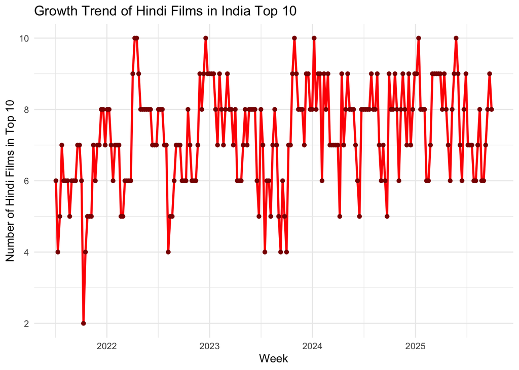

```r
us_films <- COUNTRY_TOP_10 %>%
  filter(country_name == "United States", category == "Films") %>%
  distinct(show_title)


india_films <- COUNTRY_TOP_10 %>%
  filter(country_name == "India", category == "Films")

hindi_films <- india_films %>%
  filter(!show_title %in% us_films$show_title)


hindi_trend <- hindi_films %>%
  group_by(week) %>%
  summarise(
    num_films = n_distinct(show_title),
    .groups = "drop"
  ) %>%
  arrange(week)

ggplot(hindi_trend, aes(x = week, y = num_films)) +
  geom_line(color = "red", size = 1) +
  geom_point(color = "darkred") +
  labs(
    title = "Growth Trend of Hindi Films in India Top 10",
    x = "Week",
    y = "Number of Hindi Films in Top 10" ) + theme_minimal()
```

## Netflix’s footprint in Argentina shines

```r
# Analyze the playback volume of the top three videos in the region with the longest playback time.
long_service_country <- COUNTRY_TOP_10 |>
  group_by(country_name) |>
  summarise(total_weeks = n_distinct(week), .groups = "drop") |>
  filter(total_weeks > 200) |>
  arrange(total_weeks)

cease_date <- COUNTRY_TOP_10 |>
  filter(country_name == long_service_country$country_name[1]) |>
  summarise(last_week = max(week))


ARG <- "Argentina"


week_col <- if ("week" %in% names(COUNTRY_TOP_10)) "week" else
            if ("week_start" %in% names(COUNTRY_TOP_10)) "week_start" else
            stop("COUNTRY_TOP_10  week ")

argentina_films <- COUNTRY_TOP_10 |>
  filter(
    str_to_lower(country_name) == str_to_lower(ARG),
    str_detect(category, regex("\\bFilms\\b", ignore_case = TRUE))
  ) |>
  group_by(show_title) |>
  summarise(
    weeks_in_argentina = n_distinct(.data[[week_col]]),
    .groups = "drop"
  ) |>
  arrange(desc(weeks_in_argentina))


wk_gt <- if ("week" %in% names(GLOBAL_TOP_10)) "week" else
         if ("week_start" %in% names(GLOBAL_TOP_10)) "week_start" else
         stop("GLOBAL_TOP_10  week ")

GT_hours <- GLOBAL_TOP_10 |>
  transmute(
    show_title  = str_squish(show_title),
    week_date   = as.Date(.data[[wk_gt]]),
    global_hours = as.numeric(weekly_hours_viewed)
  )

ARG_weekly <- COUNTRY_TOP_10 |>
  filter(str_to_lower(country_name) == str_to_lower(ARG)) |>
  transmute(
    show_title = str_squish(show_title),
    week_date  = as.Date(.data[[week_col]])
  ) |>
  left_join(GT_hours, by = c("show_title","week_date")) |>
  mutate(global_hours = coalesce(global_hours, 0))
top3_titles <- ARG_weekly |>
  group_by(show_title) |>
  summarise(
    total_hours = sum(global_hours, na.rm = TRUE),
    total_weeks = n_distinct(week_date),
    .groups = "drop"
  ) |>
  arrange(desc(total_hours)) |>
  slice_head(n = 3)


head(argentina_films, 10)
```

```
# A tibble: 10 × 2
   show_title                            weeks_in_argentina
   <chr>                                              <int>
 1 KPop Demon Hunters                                    15
 2 The Secret Life of Pets 2                             11
 3 Sing 2                                                10
 4 Despicable Me 3                                        8
 5 Hotel Transylvania 3: Summer Vacation                  8
 6 All Quiet on the Western Front                         7
 7 Dr. Seuss' The Grinch                                  7
 8 Minions: The Rise of Gru                               7
 9 Paw Patrol: The Movie                                  7
10 Society of the Snow                                    7
```

```r
top3_titles
```

```
# A tibble: 3 × 3
  show_title      total_hours total_weeks
  <chr>                 <dbl>       <int>
1 Stranger Things  7349340000          10
2 Squid Game       7106450000          23
3 Bridgerton       4720390000          15
```